# Time Series

## White noise process

The most basic time series that we will encounter is a so called white noise process, which is a stochastic process in which all $X_t$ are iid $\mathcal{N(0,\sigma^2)}$.

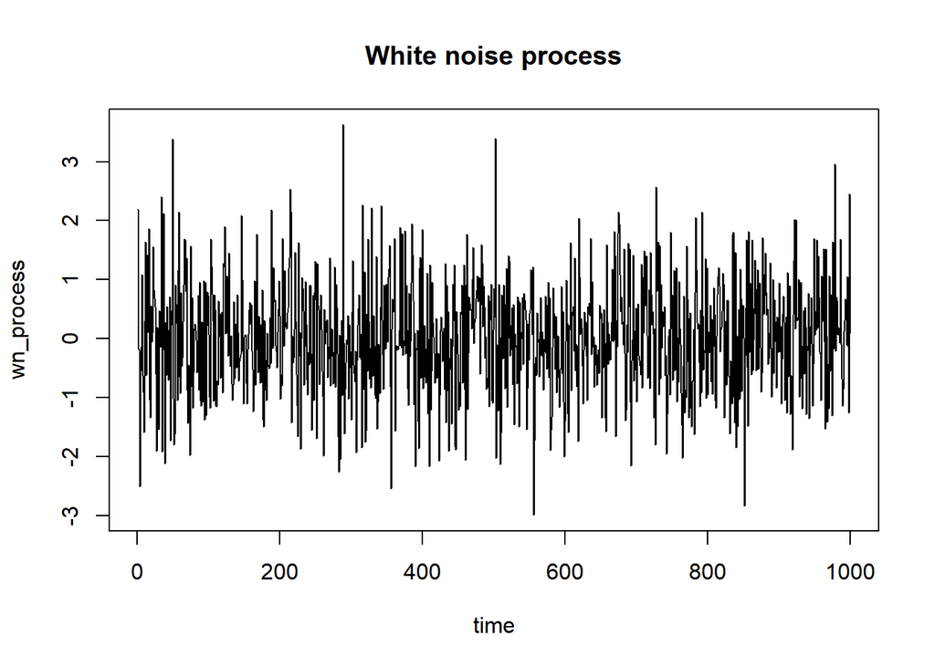

```r
set.seed(1001)
wn_process<-ts(rnorm(1000,0,1))
plot(wn_process,main="White noise process",xlab="time")
```

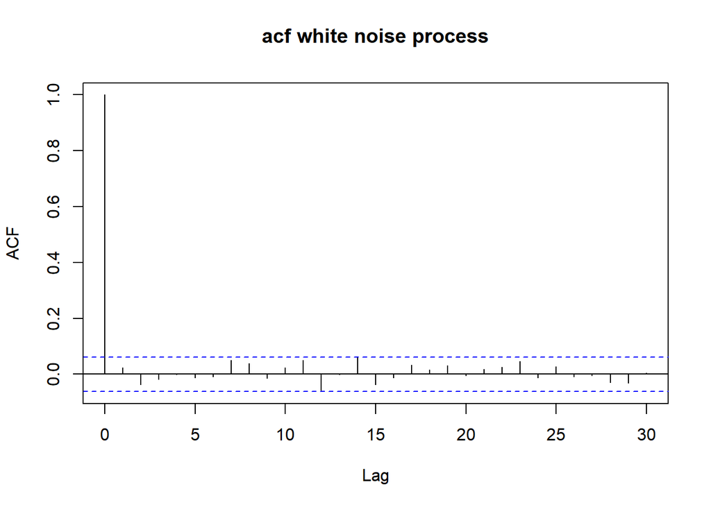

```r
acf(wn_process,main="acf white noise process")
```

```r
mean(wn_process) #Mean estimate
```

```
## [1] 0.02195829
```

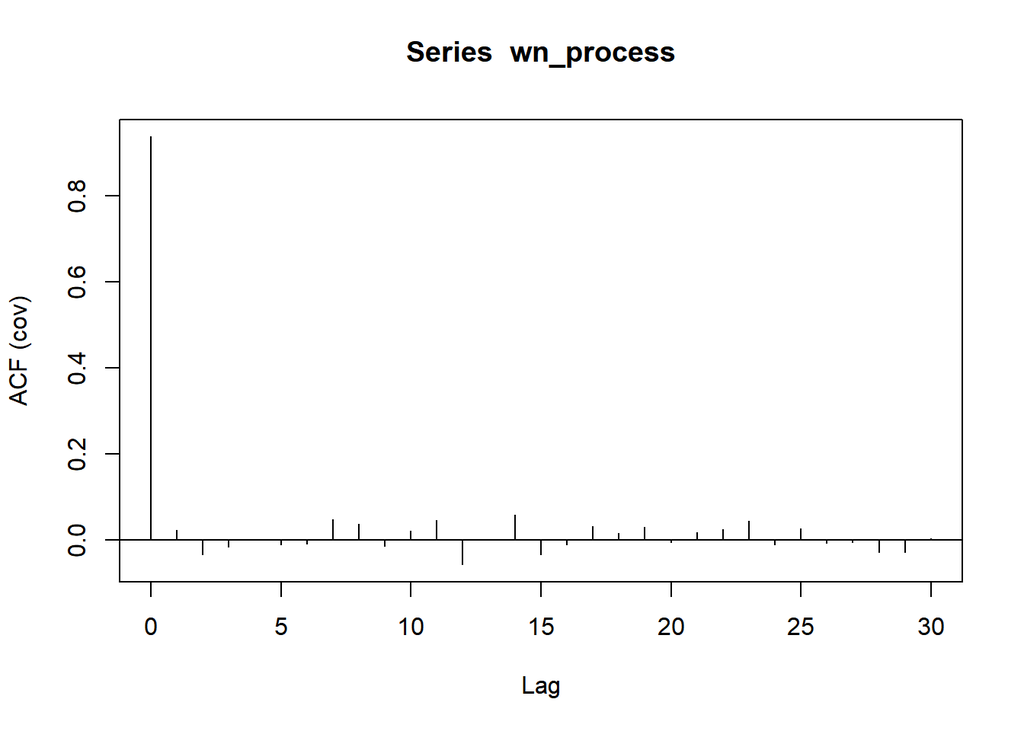

```
## [1] 0.9364047
```

```r
acf(wn_process,type="covariance")$acf[1] #Variance estimate
```

## Random walk

A random walk can be seen as a cumulative white noise process.

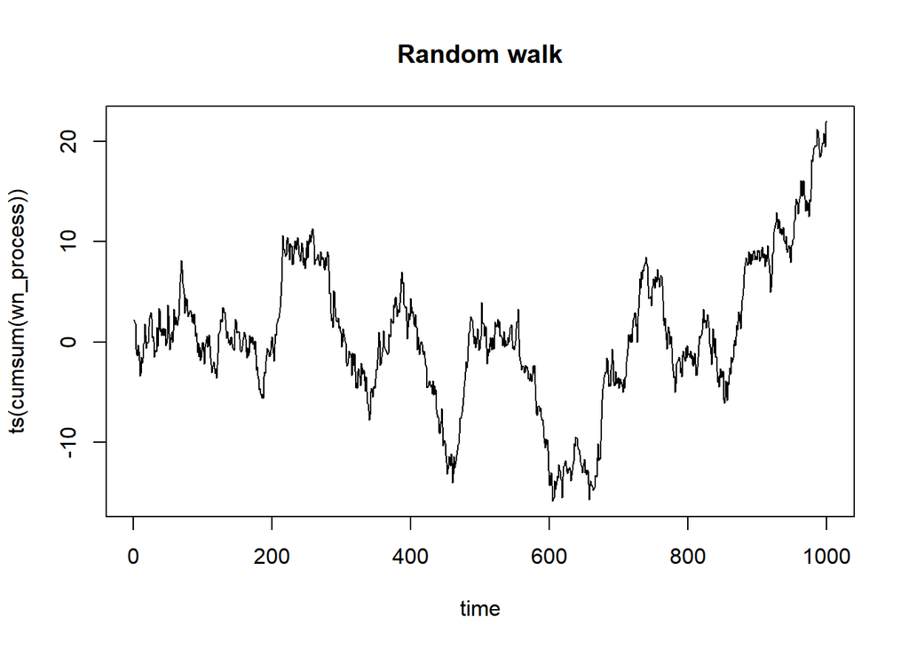

```r
plot(ts(cumsum(wn_process)),main="Random walk",xlab="time")
```

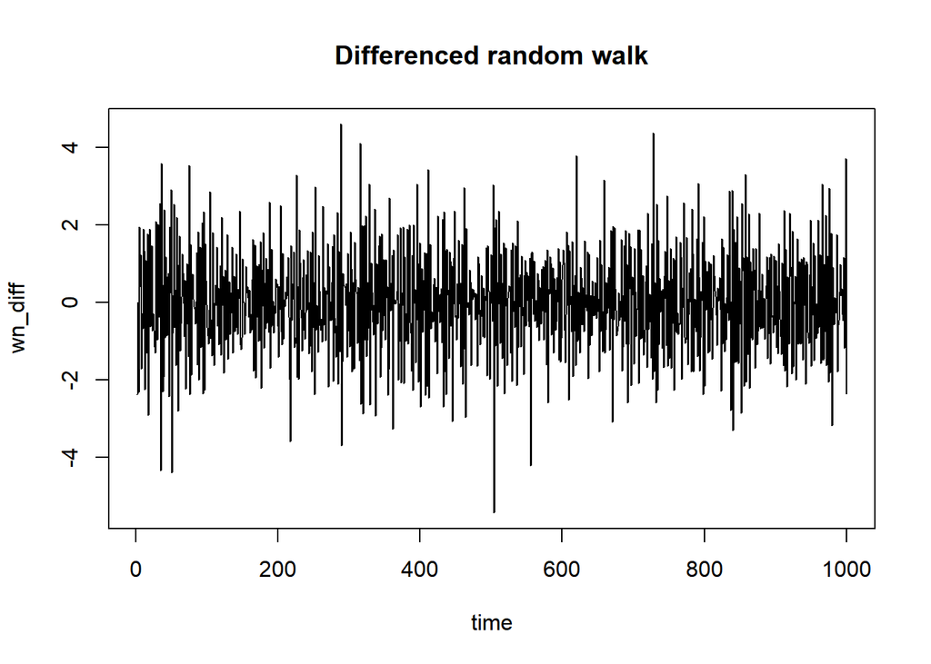

```r
#Note that the random walk is not stationary (i.e. moment characteristics of the series changes over time), however it is I(1), so (first-order) differencing yields a stationary series
wn_diff=diff(wn_process)
plot(wn_diff,main="Differenced random walk",xlab="time")
```

## AR(p) model

An autoregressive model of order p has the form $X_t=c+\sum_{i=1}^{p}\phi_iX_{t-i}+\epsilon_t$, where $\epsilon_t$ is a white noise process with variance $\sigma_t$ and the $\phi_j$ denote weights.

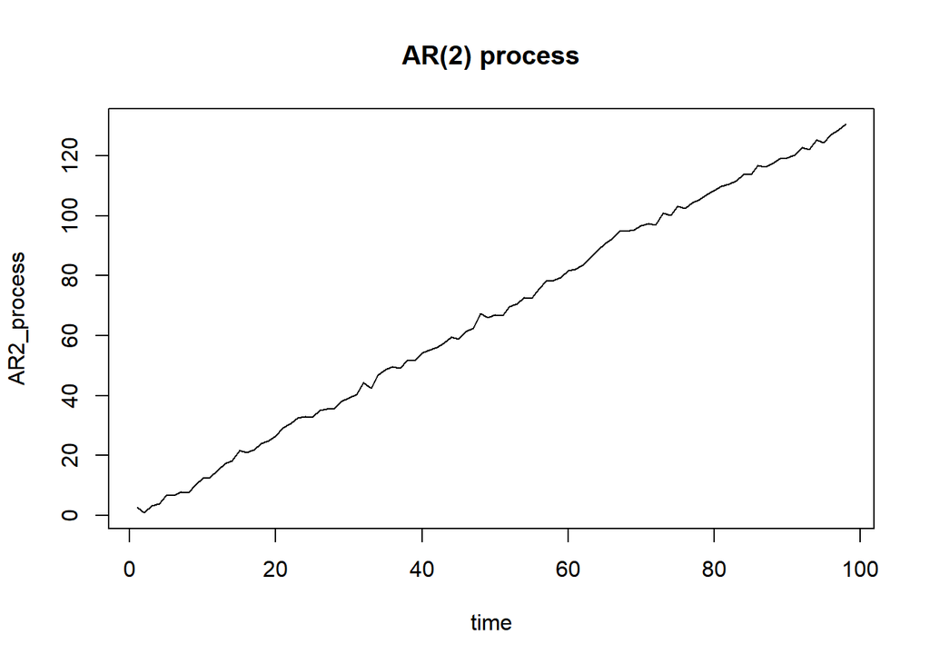

```r
set.seed(1001)
wn<-rnorm(200)
Xt<-c(wn[1],wn[2])

for(i in 3:100){
  Xt[i]=2+0.5*Xt[i-1]+0.5*Xt[i-2]+wn[i]
}

AR2_process=ts(Xt[3:100])
plot(AR2_process,main="AR(2) process",xlab="time")
```

## MA(p) model

A moving average model of order p has the form $X_t=c+\sum_{i=1}^{p}\theta_i \epsilon_{t-i}$ in which $\theta_i$ denote weights. Below a MA(3) process is simulated, note that autocorrelation is observed to be significant until for past three lags.

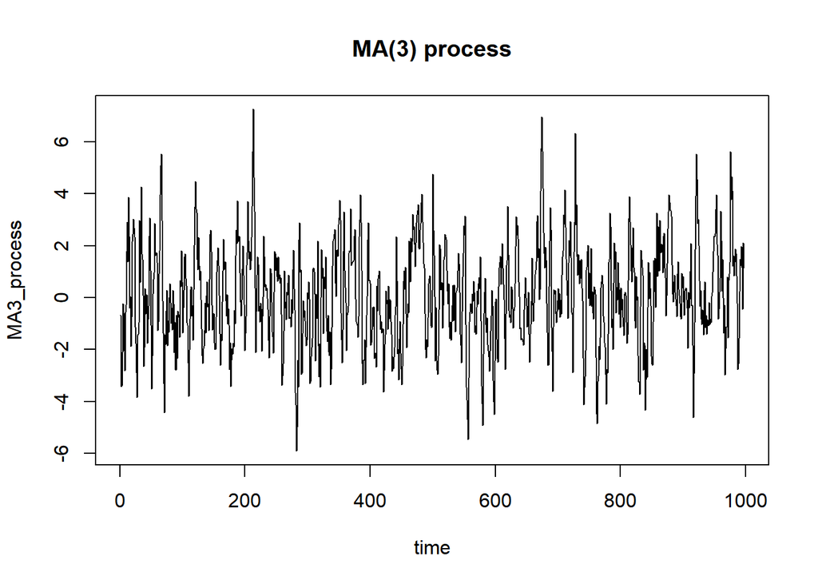

```r
xt=NULL

for(i in 4:1000){
  xt[i]=wn_process[i]+wn_process[i-1]+wn_process[i-2]+wn_process[i-3]
}

MA3_process=ts(xt[4:1000])
plot(MA3_process,main="MA(3) process",xlab="time")
```

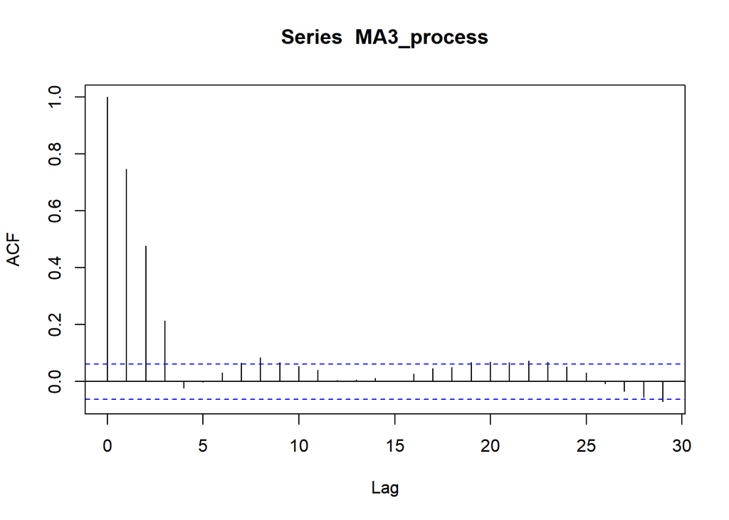

```r
#Without the acf it would be impossible to see that this is a MA(3) process from the plot
acf(MA3_process,type="correlation")
```

A moving average process can be used for time series smoothing as can be seen in the example below. The larger the order of the series, the more the time series is averaged and thus smoothed.

```r
require("forecast")
```

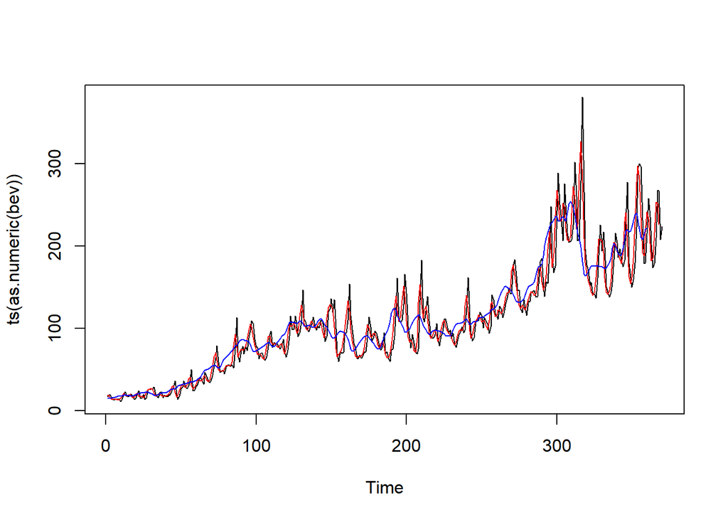

```r
data(bev)
plot(ts(as.numeric(bev))) #For convenience leave out x values (years)
lines(as.numeric(na.omit(ma(bev,order=2))),col="red")
lines(as.numeric(na.omit(ma(bev,order=10))),col="blue")
```

```r
#Note that the second line is much smoother
```

## ARMA(p,q) and ARIMA(p,d,q) process

The ARMA(p,q) process is the combination of an AR(p) and MA(q) process, while the ARIMA(p,d,q) applies a d order differencing on the response. In below cases ARMA and ARIMA processes will be simulated. For efficiency the parameters and coefficients will be estimated using R functions.

```r
phi_1<-0.6;phi_2<-0.3
q_1<-0.5;q_2<-0.4
sigma=1
set.seed(1001)
ARMA_2_2<-arima.sim(n = 10000, list(ar = c(phi_1, phi_2),ma=c(q_1,q_2)),sd=sigma)

#Both the acf and pacf are tailing off. As a result the right orders can't be infered from them, but it indicates that the process is unlikely to be just AR(p) or MA(q).

#For higher order processes, auto.arima can have difficulties in estimating the right orders. For (p,q)=(2,2) the estimation is still quite accurate.
auto.arima(ARMA_2_2)
```

[output not shown]

```
## Series: ARMA_2_2
## ARIMA(2,0,2) with zero mean
##
## Coefficients:
##          ar1     ar2     ma1     ma2
##       0.5681  0.3246  0.5301  0.3868
## s.e.  0.0247  0.0240  0.0231  0.0096
##
## sigma^2 estimated as 0.9951:  log likelihood=-14164.1
## AIC=28338.2   AICc=28338.21   BIC=28374.26
```

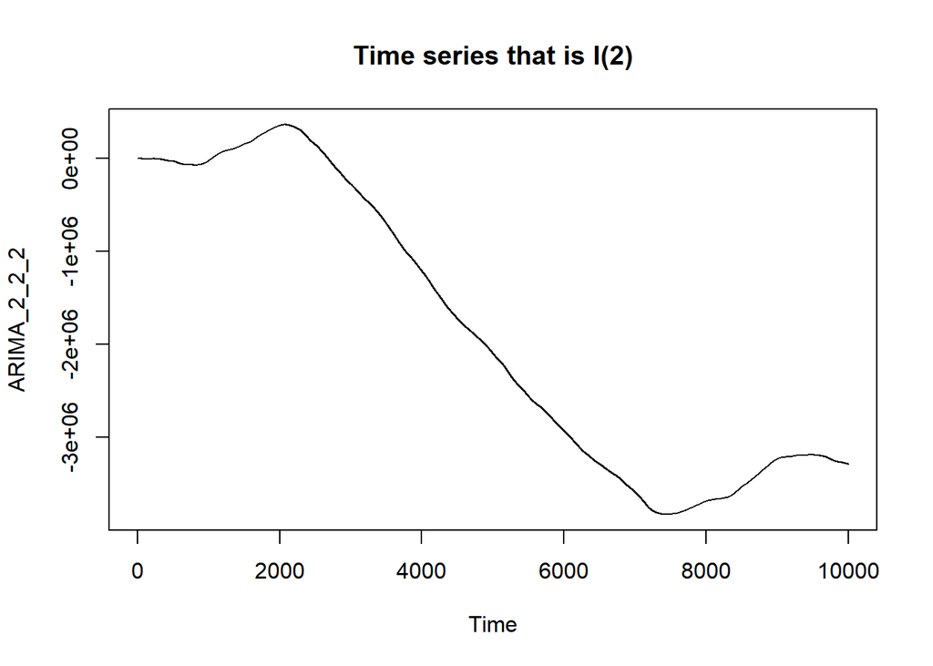

```r
#Now look at a process that is integrated of order 2.
set.seed(1001)
ARIMA_2_2_2<-arima.sim(n = 10000, list(ar = c(phi_1, phi_2),order=c(2,2,2),ma=c(q_1,q_2)),sd=sigma)

#The plot clearly shows that it is not a stationary time series
plot(ARIMA_2_2_2,main="Time series that is I(2)")
```

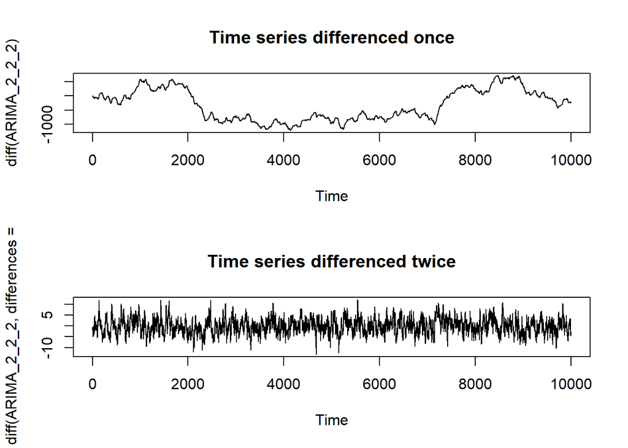

```r
#Examine now the plot for the differenced time series
par(mfrow=c(2,1))
plot(diff(ARIMA_2_2_2),main="Time series differenced once")
plot(diff(ARIMA_2_2_2,differences=2),main="Time series differenced twice")
```

```r
#Use that twice differenced ARIMA series is ARMA
auto.arima(diff(ARIMA_2_2_2,differences=2))
```

```
## Series: diff(ARIMA_2_2_2, differences = 2)
## ARIMA(2,0,2) with zero mean
##
## Coefficients:
##          ar1     ar2     ma1     ma2
##       0.5681  0.3246  0.5301  0.3868
## s.e.  0.0247  0.0240  0.0231  0.0096
##
## sigma^2 estimated as 0.9951:  log likelihood=-14164.1
## AIC=28338.2   AICc=28338.21   BIC=28374.26
```

## Estimation of time series coefficients

In order to estimate coefficients of time series, the following steps need to be taken:

- A model needs to be chosen, i.e. it needs to be assessed what type of time series has generated the data.
- The order of the time series needs to be assessed.
- The coefficients of the time series need to be assessed for determined order under previous bullet.

## Assessing the order of the series

In assessing the order of the time series, different approaches can be used. It can be visually examined what the order of the series is, but also Goodness-Of-Fit (GOF) measures can be examined for different order models. Below both approaches will be shown.

In visually assessing the order of the series the acf is useful for MA series, but not directly for AR series as can be seen in the example below.

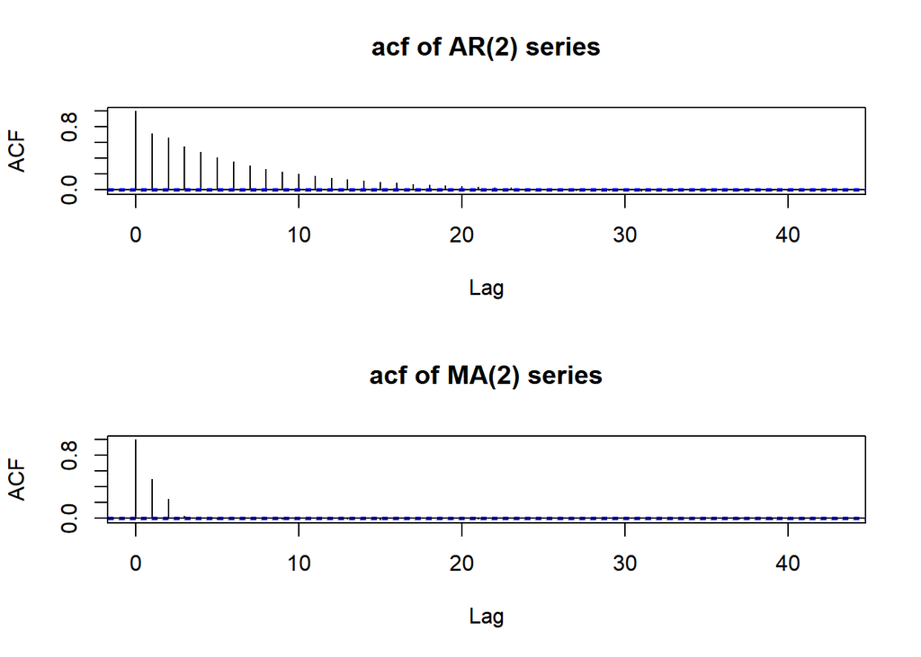

```r
#For efficiency the function arima.sim is used for simulation of the data
set.seed(1001)
phi_1=0.5
phi_2=0.3
sigma=1
AR_2<-arima.sim(n = 20000, list(ar = c(phi_1, phi_2)),sd=sigma)
MA_2<-arima.sim(n = 20000, list(ma = c(phi_1, phi_2)),sd=sigma)
par(mfrow=c(2,1))
acf(AR_2,main="acf of AR(2) series")
acf(MA_2,main="acf of MA(2) series")
```

In case of AR series it is useful to look at the so called Partial Auto-Correlation Function (PACF) in which indirect effects are partialled out as can be seen in the example below. In this example it will be used as a given that the data is generated by a AR process.

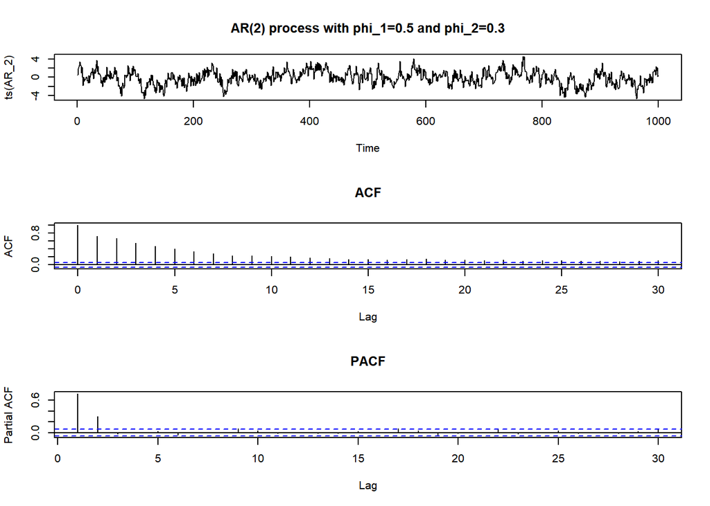

```r
#For efficiency the function arima.sim is used for simulation of the data
phi_1=0.5
phi_2=0.3
sigma=1
AR_2<-arima.sim(n=1000,list(ar=c(phi_1,phi_2)),sd=sigma)

#Note that p=1 and 2 are significant for the PACF
par(mfrow=c(3,1))
plot(ts(AR_2),main="AR(2) process with phi_1=0.5 and phi_2=0.3")
acf(AR_2,type="correlation",main="ACF")
acf(AR_2,type="partial",main="PACF")
```

To summarize using the ACF and PACF in assessing lags: - For an AR(p) model the ACF tails off, while the PACF cuts off after p lags - For an MA(p) model the PACF tails off, while the ACF cuts off after q lags - For an ARMA(p,q) model both the ACF and PACF tail off as result of previous two points.

In case of the third bullet, one knows that an ARMA estimation approach function needs to be applied, as the visual autocorrelation plots will not be helpful for the estimation of the lags. One could for example use GOF optimization strategies.

The AIC is a common GOF measure for time series and can be used in order to examine the order of a series. For convenience we show this GOF for an AR process.

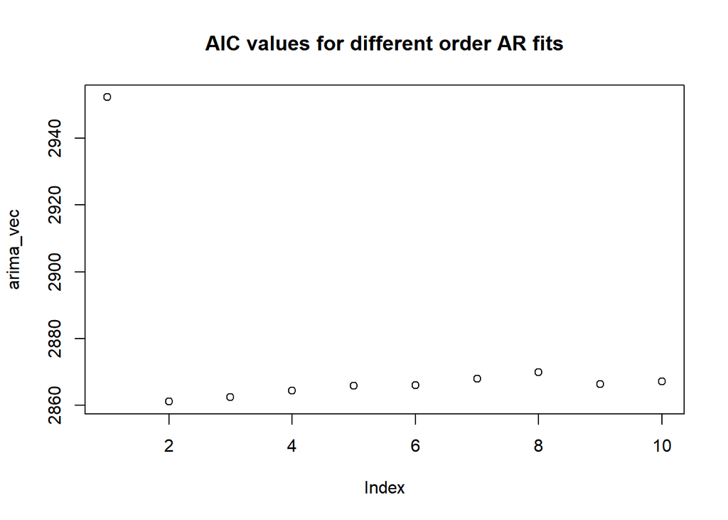

```r
arima_vec<-c()

for(i in 1:10){
  aic<-arima(AR_2,order=c(i,0,0))$aic
  arima_vec<-c(arima_vec,aic)
}
plot(arima_vec,main="AIC values for different order AR fits")
```

```r
#Here the order is determined based on the index of the minimum AIC, but generally it is also good to keep the parsimony principle in mind and test whether the decrease in AIC relatively to the last order is sufficient to add another coefficient to the model.
paste("AIC is minimal for order",which.min(arima_vec))
```

```
## [1] "AIC is minimal for order 2"
```

```r
#The function auto.arima provides an efficient approach to select the optimal order
auto.arima(AR_2,max.q=0)
```

```
## Series: AR_2
## ARIMA(2,0,0) with zero mean
##
## Coefficients:
##          ar1     ar2
##       0.5073  0.2987
## s.e.  0.0301  0.0302
##
## sigma^2 estimated as 1.017:  log likelihood=-1426.73
## AIC=2859.46   AICc=2859.49   BIC=2874.19
```